# Census Bilingualism Analysis

## 3.4. summary tables: children under 9 years

| LangGroup_individual | N | Percent |
| --- | --- | --- |
| One Language | 29563 | 0.837478754 |
| Two or more | 5706 | 0.161643059 |
| NA | 31 | 0.000878187 |

```
Column `LangPair_isimplified` joining character vector and factor, coercing into character vector
```

[output not shown]

[output cut: 6 more lines]

# 4. poster plots

## 4.1. plot maps

### 4.1.1. get canada map data

```
Column `CMA` joining factor and character vector, coercing into character vector
```

`r`r # code taken from: https://stackoverflow.com/questions/29421436/adding-provinces-to-canadian-map-in-r if (!file.exists(./src/ref/ne_50m_admin_1_states_provinces_lakes/ne_50m_admin_1_states_provinces_lakes.dbf)){ download.file(file.path(‘http://www.naturalearthdata.com/http/’, ‘www.naturalearthdata.com/download/50m/cultural’, ‘ne_50m_admin_1_states_provinces_lakes.zip’), f <- tempfile()) unzip(f, exdir = ./src/ref/ne_50m_admin_1_states_provinces_lakes) rm(f) } region <- readOGR(./src/ref/ne_50m_admin_1_states_provinces_lakes, ‘ne_50m_admin_1_states_provinces_lakes’, encoding=‘UTF-8’)

```
Source: \C:\Users\e_schot\Documents\R Files\BilingalismCanada\src\ref\ne_50m_admin_1_states_provinces_lakes\, layer: \ne_50m_admin_1_states_provinces_lakes\
```

### 4.1.3. plot map

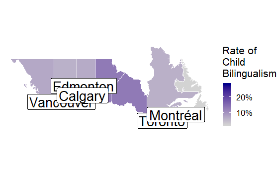

## 4.2. bubble charts

currently, I create the map for each province separately. There is probably a more elegant solution. also, need to make size of circles proportional across provinces (so can compare size of bubbles across provinces) ### 4.2.0 formatting settings

`r`r circle.plot.height= 4

### 4.2.1. quebec

`r`r # QUEBEC plot.languagePairs = circleProgressiveLayout(hdata_child_langPair[hdata_child_langPair$PR==,])

```
missing and/or non-positive sizes will be ignored
```

`r`r circles_layout <- circleLayoutVertices(plot.languagePairs) circles_layout = left_join(circles_layout, hdata_child_langPair[hdata_child_langPair$PR == , c(,_code)])

[figure not shown]

### 4.2.2. bc

`r`r # British Columbia plot.languagePairs = circleProgressiveLayout(hdata_child_langPair[hdata_child_langPair$PR==Columbia,])

```
missing and/or non-positive sizes will be ignored
```

`r`r circles_layout <- circleLayoutVertices(plot.languagePairs) # add colour code circles_layout = left_join(circles_layout, hdata_child_langPair[hdata_child_langPair$PR == Columbia, c(,_code)])

`r`r # add labels back in plot.languagePairs = cbind(plot.languagePairs, langPair=hdata_child_langPair$LanguagePairing1 [hdata_child_langPair$PR==Columbia] ) plot.languagePairs$langPair.fixed =gsub(\ \,\\n\,plot.languagePairs$langPair) plot.BC = ggplot(circles_layout, aes(x, y)) + geom_polygon(aes(group = id,fill=factor(Colour_code)), colour = , show.legend = FALSE) + geom_text(data = plot.languagePairs, aes(x, y, fontface=2,lineheight=.8), label = plot.languagePairs$langPair.fixed) + theme_void(base_size=26)+ scale_fill_manual(values = c(#ef8a62, #af8dc3, #67a9cf))+ ggtitle(Columbia)+ coord_fixed() theme(plot.title = element_text(hjust = 0.5))

[output not shown]

`r`r plot.BC ggsave(2_output/LangPairs_BC.png, width=3.5,height=circle.plot.height)

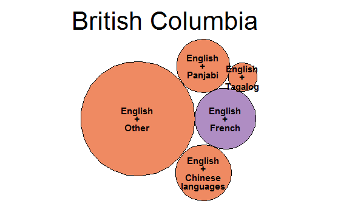

### 4.2.3. ontario

`r`r # ontario plot.languagePairs = circleProgressiveLayout(hdata_child_langPair[hdata_child_langPair$PR==,])

```
missing and/or non-positive sizes will be ignored
```

`r`r circles_layout <- circleLayoutVertices(plot.languagePairs) # add colour code circles_layout = left_join(circles_layout, hdata_child_langPair[hdata_child_langPair$PR == , c(,_code)])

`r`r # add labels back in plot.languagePairs = cbind(plot.languagePairs, langPair=hdata_child_langPair$LanguagePairing1 [hdata_child_langPair$PR==], fill.var = hdata_child_langPair$Colour_code [hdata_child_langPair$PR==]) plot.languagePairs$langPair.fixed =gsub(\ \,\\n\,test$langPair) plot.ontario = ggplot(circles_layout, aes(x, y)) + geom_polygon(aes(group = id, fill=factor(Colour_code)), colour = , show.legend = FALSE) + geom_text(data = plot.languagePairs, aes(x, y, fontface=2,lineheight=.8), label = plot.languagePairs$langPair.fixed) + theme_void(base_size=26)+ scale_fill_manual(values = c(#ef8a62, #af8dc3, #67a9cf)) + ggtitle()+ coord_fixed() + theme(plot.title = element_text(hjust = 0.5)) plot.ontario ggsave(2_output/LangPairs_Ontario.png, width=5,height=circle.plot.height)

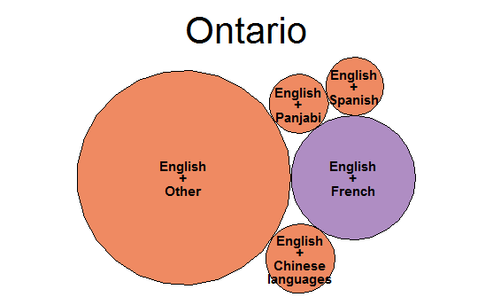

### 4.2.3.alberta

`r`r # Alberta plot.languagePairs = circleProgressiveLayout(hdata_child_langPair[hdata_child_langPair$PR==,])

```
missing and/or non-positive sizes will be ignored
```

`r`r circles_layout <- circleLayoutVertices(plot.languagePairs) # add colour code circles_layout = left_join(circles_layout, hdata_child_langPair[hdata_child_langPair$PR == , c(,_code)])

`r`r # add labels back in plot.languagePairs = cbind(plot.languagePairs, langPair=hdata_child_langPair$LanguagePairing1 [hdata_child_langPair$PR==] ) plot.languagePairs$langPair.fixed =gsub(\ \,\\n\,plot.languagePairs$langPair) plot.alberta = ggplot(circles_layout, aes(x, y)) + geom_polygon(aes(group = id, fill=factor(Colour_code)), colour = , show.legend = FALSE) + geom_text(data = plot.languagePairs, aes(x, y, fontface=2, lineheight=.8), label = plot.languagePairs$langPair.fixed) + theme_void(base_size=26)+scale_fill_manual(values = c(#ef8a62, #af8dc3, #67a9cf))+ggtitle()+theme(plot.title = element_text(hjust = 0.5)) + coord_fixed() plot.alberta ggsave(2_output/LangPairs_Alberta.png, width=4.5,height=circle.plot.height)

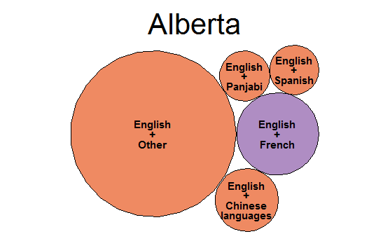

## 4.3. combine all plots & save

`r`r (plot.all = plot_grid(plot.BC, plot.alberta, plot.ontario,plot.quebec, ncol=4, align=, rel_widths = c(1,1.3,2,1)))

```
Removed 2 rows containing missing values (geom_text).Removed 2 rows containing missing values (geom_text).Removed 2 rows containing missing values (geom_text).Removed 2 rows containing missing values (geom_text).
```

[figure not shown]